# Homework 4

## Problem 1. A Data Scientist Referees Ping Pong (8pts total)

The game is Ping Pong. Players grab their paddles and hit the ping pong ball back and forth scoring points one at a time. The game continues until one player reaches 21 points, and at that point the game ends unless the point difference is less than 2. If it is less than 2 the game continues until one player wins by 2.

Suppose Athena and Bacchus play and Bacchus wins 21 to 14. Bacchus is super excited but Athena says that they should have a rematch, because she’s sure that Bacchus is not better than her, it was just a fluke.

Time for a Data Scientist to settle this dispute. We must consider two hypotheses. The null hypothesis is that they are equally skilled - thus for each point scored the probability it goes to the ultimate winner is $0.50$ (this is what Athena is claiming). The alternative is that Bacchus truly is more skilled, and the probability is greater than $0.50$ (the winner actually has more skill, and doesn’t win purely by chance).

Create a Monte Carlo simulation of a game. Use the **point difference** at game end as the test statistic.

1. (4 points) Create a function called `playPingPong` which simulates a single game of Ping Pong with equally skilled players. Remember the logic : points are given to players A or B with equal chance, and that continues until (1) the max score $\geq 21$ *and* (2) the difference between scores $\geq 2$. Have the function return the point difference.

```r
playPingPong <- function(scoreTrigger = 21, winMargin = 2, probPlayerA = 0.5) {
  scoreA = 0
  scoreB = 0
    while (max(scoreA, scoreB) < scoreTrigger | abs(scoreA - scoreB) < winMargin) {
    if (runif(1) < probPlayerA) {
      scoreA = scoreA + 1
    } else {
      scoreB = scoreB + 1
    }
  }
    return(abs(scoreA - scoreB))
}
```

2. (2 points) Perform the Monte Carlo test; simulate 1000 (or more) games with equally skilled players. Look at the distribution of point differences, and compare the observed point difference to this distribution. What is the *p*-value of the observed point difference.

```r
set.seed(123)
num_simulations = 10000
point_differences = replicate(num_simulations, playPingPong())

observed_difference = 7

p_value = mean(point_differences >= observed_difference)

p_value
```

```
## [1] 0.307
```

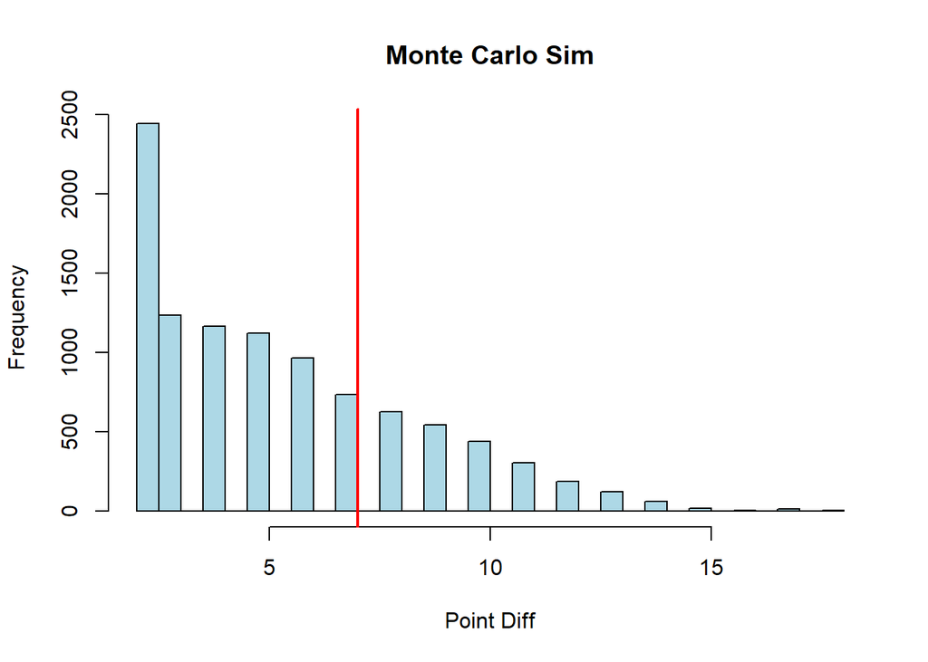

```r
hist(point_differences, breaks = 30, main = "Monte Carlo Sim",
     xlab = "Point Diff", col = "lightblue", border = "black")
abline(v = observed_difference, col = "red", lwd = 2)
```

3. (2 points) How do you conclude? Is this one game sufficient evidence that Bacchus is the superior Ping Pong Player? No, the one game is not sufficient evidence that Bacchus is the superior ping pong player (p ~ .3).

## Problem 2: Quality or Quantity? (6pts total)

**Nifty Grifty**, a local restaurant recently had an art contest where any child under the age of 12 could submit a drawing. Submissions were accepted during the month of January. The restaurant owner then looked at all submissions and the top 10 drawings were put on display. Kids were allowed to submit more than one drawing. When the winners were announced some customers were surprised that four of the 10 winners were the same kid, Paulo Pizzaco! He was even interviewed on Channel 3, lauded as an artistic prodigy.

When looking at the submissions, however, you notice that among the 150 drawings submitted that 30 of them were from Paulo. It seems he submitted a new drawing almost every day of the month!

What do you think? Is the contest evidence of the quality of his work, or a consequence of the quantity of his submissions? The contest outcome seems to be more of a consequence of the quantity of Paulo’s submissions rather than clear evidence of the quality of his work. Since he submitted 30 out of 150 drawings which is 20% of the total submissions, its not too surprising that several of his submissions ended up in the top 10.

Take the null hypothesis to be that any of the 150 considered drawings could be included in the top 10 with equal likelihood. How likely under this model would we see 4 (or more) of Paulo’s drawings in the top 10? What do you conclude?

```r
set.seed(123)
num_simulations = 10000
total_drawings = 150
paulo_drawings = 30
top_selections = 10

drawings = c(rep(1, paulo_drawings), rep(0, total_drawings - paulo_drawings))
# 1 represents a Paulo drawing while 0 represents other drawings
simulated_counts <- replicate(num_simulations, {
  sampled_top <- sample(drawings, top_selections, replace = FALSE)
  sum(sampled_top)
})

p_value = mean(simulated_counts >= 4)

p_value
```

```
## [1] 0.1177
```

```r
if (p_value < 0.05) {
  print("There is significant evidence that Paulo's drawings were selected due to quality")
} else {
  print("The selection of Paulo's drawings could be due to chance rather than quality")
}
```

```
## [1] "The selection of Paulo's drawings could be due to chance rather than quality"
```

Proceed by treating this as a formal hypothesis test. Define the null and alternative hypotheses, define your test statistic, produce a distribution of simulated test statistics from the null model and finish by calculating a *p*-value and providing your own interpretation.

Null Hypothesis: The selection of the top 10 drawings in random, meaning each of the 150 has an equal probability of being chosen Alternative Hypothesis: Paulo’s drawings are more likely to be chosen, meaning his work is of higher quality compared to the other submissions Test statistic here is the number of Paulo’s drawings appearing in the top 10 P-value is the probability that 4 or more of Paulo’s drawings would be selected by random chance If p < .05, Paulo’s work was likely selected because of it being higher quality, alternatively if p > .05, his success is likely due to the number of drawings he submitted.

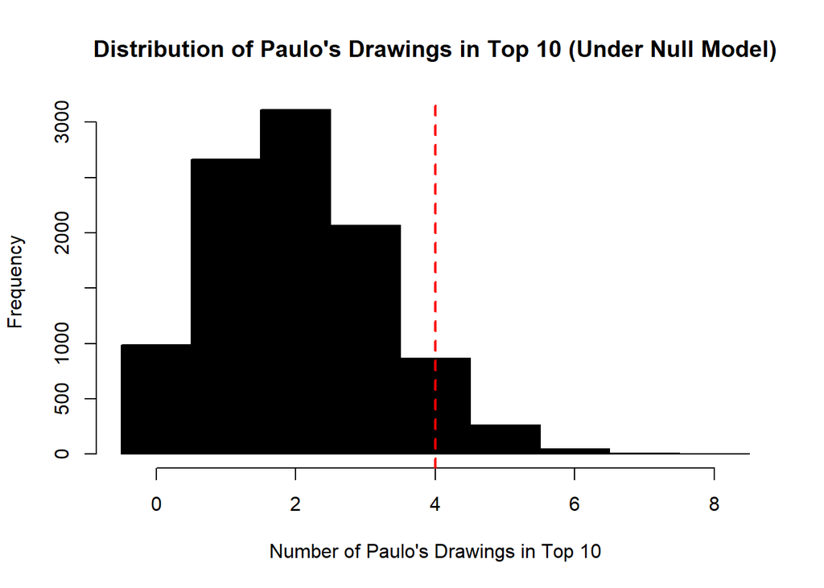

```r
hist(simulated_counts, breaks = seq(-0.5, max(simulated_counts) + 0.5,),
     main = "Distribution of Paulo's Drawings in Top 10 (Under Null Model)",
     xlab = "Number of Paulo's Drawings in Top 10",
     ylab = "Frequency",
     col = "black",)

abline(v = 4, col = "red", lwd = 2, lty = 2)
```

## Problem 3: Permutation testing (8pts)

Below are data arising from a (fictionalized) data source: the number of defects per day on an assembly line before and after installation of a new torque converter (this is a totally fictional “part” of an assembly line–just treat these as “control” and “treatment” groups, respectively).

```r
before = c(4,5,6,3,6,3,4,5,5,4,4,6,4,6,3,4,2,2,0,7,5,8,4,5,1,4,4,8,2,3)
after  = c(3,2,4,3,7,5,5,2,2,4,1,2,2,0,1,5,6,3,2,3,1,3,1,3,4,2,2,6,3,4)
```

1. (4 points) Use a permutation test to assess the claim that installation of the new part *changed* the prevalence of defects. That is, test the null hypothesis that the distribution of defects is the same before and after installation of the new part. Produce a p-value and interpret the results of your test in context.

```r
set.seed(123)
obs_diff = mean(after) - mean(before)
num_simulations = 10000
combined_data = c(before, after)
perm_diffs = replicate(num_simulations, {
  permuted = sample(combined_data)
  new_before = permuted[1:length(before)]
  new_after = permuted[(length(before) + 1):length(combined_data)]
  mean(new_after) - mean(new_before)
})

p_value = mean(abs(perm_diffs) >= abs(obs_diff))

obs_diff
```

```
## [1] -1.2
```

```r
p_value
```

```
## [1] 0.0136
```

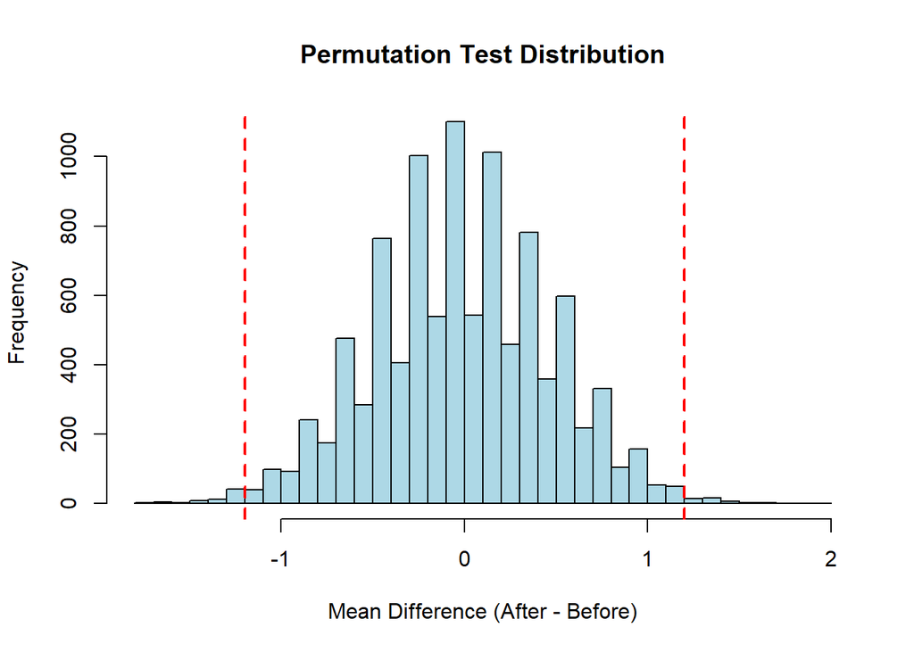

```r
hist(perm_diffs, breaks = 30, col = "lightblue", main = "Permutation Test Distribution",
     xlab = "Mean Difference (After - Before)", ylab = "Frequency")
abline(v = obs_diff, col = "red", lwd = 2, lty = 2)
abline(v = -obs_diff, col = "red", lwd = 2, lty = 2)
```

Intepretation: the p-value is less then .05, so we reject the null hypothesis at the 5% significance level. This suggests that the installation of the new torque converter significantly changed the prevalence of defects.

2. (4 points) Explain, briefly, what you did above and why. Imagine that you are trying to explain to someone who isn’t well versed in statistics what exactly you are doing in a permutation test. Explain your conclusion based on your test above. Three to five sentences should be plenty, but you are free to write as much or as little as you think is necessary to clearly explain your findings. First, we calculate the observed difference in means between the “before” and “after” groups. Next, we shuffle the combined data and randomly split it into two new groups. We then compute the difference in means for each shuffle and determine how often this shuffled difference is at least as extreme as the observed difference. The proportion of these extreme cases gives us the p-value.

## Problem 4: Memes (8pts)

The following question comes from Karl Rohe, who developed the very first version of this class. This question has been reproduced in nearly the exact original (very amusing) wording.

> **Memes, part 1** (Please forgive me. I drank too much coffee before writing this question.)

> In class thus far, there have been 416 comments posted in the bbcollaborate chat during class. An expert panel has judged 47 of these comments to be memes. The big-bad-deans say that they are concerned “if there is evidence that more than 10% of comments are memes.” So, this looks like bad news, 47/416>10%.

> Karl pleads with the deans: “Please, oh please, you big-bad-deans… Memeing is totally random.” (I don’t actually know what this notion of “random” means, but please just run with it for this question.) Then, along comes you, a trusty and dedicated 340 student. You say that “because we have only observed 416 comments, we don’t really know what the ‘true proportion’ of memes.”

> 4a: What would be a good distribution for the number of memes? Binomial distribution 4b: Using your distribution from 4a, test the null hypothesis that the ‘true proportion’ is actually 10%. It’s all up to you now… report the p-value.

```r
n_comments = 416
p_meme = 0.10
observed_memes = 47

num_simulations = 1e4
simulated_memes = rbinom(num_simulations, size = n_comments, prob = p_meme)
p_value = mean(simulated_memes >= observed_memes)
p_value
```

```
## [1] 0.2043
```

Hints:

- For 4a, there should be a (hopefully) fairly intuitive choice of random variable that makes sense here. Look at your list of random variables and ask yourself which of these makes the most sense.
- For 4b, you can use the built-in function in R to simulate observations according to your null. Remember that you **always simulate *assuming* the null hypothesis**. Make sure your choice of the necessary parameter(s) reflects this assumption.